Skip to main content

Think Python

- .ipynb

# 4b. Prof. Rosenthal’s Review

# 4b. Prof. Rosenthal’s Review

A review of [Chapter 4: Functions and Interfaces](https://y-rosenthal.github.io/yrThinkPython/chap04.html), for students who have already studied the chapter. Use the two lists under **Concepts covered** as a checklist (click a list’s title to hide it), then work through the **Questions**, which go from easy to hard. Each question has a suggested answer under **Answer**. Try the question first, then open the Answer.

[Run this page on Colab](https://colab.research.google.com/github/y-rosenthal/yrThinkPython/blob/v3/yr/chap04_review.ipynb)

## Concepts covered

Python Syntax and Semantics

**Importing**

- `import MODULE_NAME` makes a module’s functions available as `MODULE_NAME.FUNCTION_NAME(...)`. For example, after `import jupyturtle` you can call `jupyturtle.forward(100)`.
- `from MODULE_NAME import NAME1, NAME2` makes only the listed functions available, by their names alone. For example, after `from jupyturtle import forward` you can call `forward(100)`. It does not define the name `MODULE_NAME`.
- `import math` makes `math.pi` (the number pi, 3.14159…) available.

**The jupyturtle module** (turtle graphics in Jupyter and Colab)

- `make_turtle()` starts a new drawing, with the turtle in the middle, facing east (to the right).
- `make_turtle` takes optional keyword arguments: `delay=SECONDS` (pause after each step; default `0.2`; `0` is fastest), `width=PIXELS`, `height=PIXELS`, and `auto_render=False` (show the drawing only when `render()` is called).
- `forward(DISTANCE)` moves the turtle and draws a line. A negative distance moves it backward.
- `left(DEGREES)` and `right(DEGREES)` turn the turtle.
- `penup()` stops drawing as the turtle moves; `pendown()` starts drawing again.

**for loops and range**

- This repeats the indented code SOME_INTEGER times:

  ```
  for i in range(SOME_INTEGER):
      SOME_CODE
      SOME_MORE_CODE
  ```

  For example, this prints `hello` three times:

  ```python
  for i in range(3):
      print('hello')
  ```

- `range(SOME_INTEGER)` is shorthand for the integers `0, 1, 2, ...` up to SOME_INTEGER minus 1. The loop variable (`i`) takes these values in turn: in `for i in range(4):`, `i` is `0`, then `1`, then `2`, then `3`.
- `range` needs an integer: `range(4.5)` is a `TypeError`. `range(0)` and `range(-4)` produce no values, so the loop body runs zero times.

**Functions with parameters**

- This defines a function with two parameters:

  ```
  def FUNCTION_NAME(PARAMETER1, PARAMETER2):
      BODY
  ```

  The body runs only when the function is called.
- `FUNCTION_NAME(ARGUMENT1, ARGUMENT2)` calls it: the arguments are assigned to the parameters, in order.
- A function can call other functions. Each call finishes before the next statement runs.

**Keyword arguments**

- `FUNCTION_NAME(PARAMETER_NAME=VALUE)` passes an argument by naming its parameter, as in `polygon(n=7, length=30)`. With keyword arguments, the order does not matter.
- Positional arguments (without names) must come first: `polygon(n=7, 30)` is a `SyntaxError`.
- Each parameter gets one value: `polygon(30, n=7)` is a `TypeError`. So is a name that is not a parameter: `polygon(7, size=30)`.

**Local variables**

- Parameters, and variables assigned inside a function, are local to one call of the function. The same name in two functions means two different variables.
- Assigning a new value to a parameter does not change the caller’s variable.

**Division**

- `/` always produces a float: `360 / 4` is `90.0`.
- Dividing by zero, as in `360 / 0`, is a `ZeroDivisionError`.

**Docstrings and multiline strings**

- `"""TEXT"""` (triple quotes) is a string that can span several lines.
- A string on the first line of a function’s body is the function’s docstring:

  ```
  def FUNCTION_NAME(PARAMETERS):
      """WHAT THE FUNCTION DOES"""
      BODY
  ```

- A docstring is not displayed when the function runs. `help(FUNCTION_NAME)` displays it.

Definitions, etc.

**Definitions**

- DEFINITION: **Encapsulation** is wrapping a sequence of statements in a function definition.
- DEFINITION: **Generalization** is replacing something unnecessarily specific (such as a number) with something more general (such as a parameter).
- DEFINITION: A **keyword argument** is an argument that includes the name of the parameter.
- DEFINITION: **Refactoring** is changing working code to improve it (for example, its function interfaces) without changing what it does.
- DEFINITION: The **interface** of a function is how it is used: its name, its parameters, and what it does.
- DEFINITION: The **implementation** of a function is how it does what it does.
- DEFINITION: **Interface design** is deciding on a function’s interface, including which parameters it takes.
- DEFINITION: A **docstring** is a string at the beginning of a function that explains its interface.
- DEFINITION: A **multiline string** is a string in triple quotes, which can span more than one line.
- DEFINITION: A **precondition** is a requirement the caller must satisfy before a function starts.
- DEFINITION: A **postcondition** is something a function guarantees when it ends: its intended effect and any side effects.
- DEFINITION: A **stack diagram** shows the function calls in progress, one frame per call, with each call’s parameters and their values.
- DEFINITION: A **development plan** is a process for writing programs.

**Other ideas**

- Encapsulation gives code a name that documents it, and calling a function twice is shorter than copying its code.
- Two functions can have the same interface and different implementations.
- The “encapsulation and generalization” development plan:
  1. Write a small program with no function definitions.
  2. When it works, put a coherent piece of it in a function and give the function a name.
  3. Generalize the function by adding parameters.
  4. Repeat steps 1 to 3 until you have a set of working functions.
  5. Look for chances to refactor, for example by replacing similar code in several places with one general function.
- That plan is useful when you don’t know in advance how to divide a program into functions.
- Refactoring is normal: often you don’t know enough at the start of a project to design all the functions.
- A good docstring says what the function does (not how), what each parameter means, and each parameter’s type if it is not obvious. If a function is hard to explain, its interface may need improving.
- An interface is like a contract: the caller provides certain arguments and the function does certain work.
- If the caller breaks a precondition, the bug is in the caller. If the preconditions hold but a postcondition does not, the bug is in the function.

## Questions

Some questions draw pictures with `jupyturtle`, a small turtle-graphics module for Jupyter notebooks. The turtle starts in the middle of the canvas, facing east (to the right). `make_turtle()` starts a new drawing, `forward(d)` moves the turtle `d` units while drawing a line, `left(a)` and `right(a)` turn it `a` degrees, and `penup()` and `pendown()` stop and restart the drawing.

The setup cell below downloads `jupyturtle` and imports the functions the questions use.

```python
from os.path import basename, exists

def download(url):
    filename = basename(url)
    if not exists(filename):
        from urllib.request import urlretrieve

        local, _ = urlretrieve(url, filename)
        print("Downloaded " + str(local))
    return filename

download('https://github.com/ramalho/jupyturtle/releases/download/2024-03/jupyturtle.py');

import math
from jupyturtle import make_turtle, forward, left, right, penup, pendown
```

### Question 1 (easy): what is displayed?

Predict what this code displays, then open the Answer to check.

```python
for n in range(3, 7):
    print(n, 360 / n)
```

Answer

```
3 120.0
4 90.0
5 72.0
6 60.0
```

The `/` operator always produces a float, even when the division comes out even, so `360 / 4` is `90.0`, not `90`. Each `print` displays its two values separated by a space.

**By the way:** `360 / n` is the number of degrees a turtle must turn at each corner to draw a regular polygon (all sides and angles equal) with `n` sides. Some of the later questions use this.

### Question 2 (easy): what is drawn?

Describe the drawing this code makes, then open the Answer to check.

```python
make_turtle()
for i in range(3):
    forward(60)
    left(120)
```

Answer

An equilateral triangle (three equal sides) with sides of length `60`:

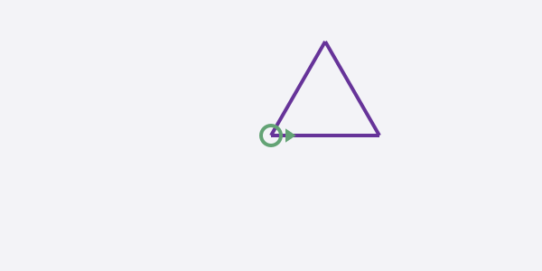

The turtle starts facing east, so the first side goes to the right. Each `left(120)` turns it counterclockwise, so the triangle is drawn above the starting line. Three turns of `120` degrees add up to `360`, a full turn, so the turtle ends where it started, facing east again.

### Question 3 (easy): write a function

Write a function called `triangle` that takes a parameter `length` and draws an equilateral triangle with that side length.

Start from this header (replace `...` with the body):

```python
def triangle(length):
    ...
```

**Examples**

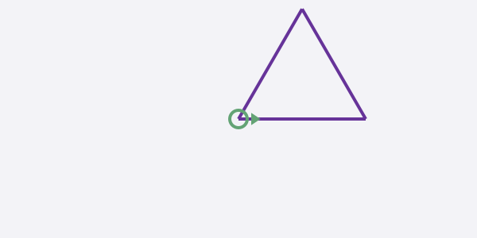

```python
make_turtle()
triangle(80)
```

[figure not shown]

```python
make_turtle()
triangle(30)
```

Answer

Use a loop that draws a side and turns `120` degrees, three times, with the parameter as the side length:

```python
from jupyturtle import forward, left

def triangle(length):
    for i in range(3):
        forward(length)
        left(120)
```

Then try: `make_turtle()` and `triangle(80)`.

Another approach: write a general `polygon` function first, then use it. `triangle` works exactly the same way (same interface), with a different implementation:

```python
from jupyturtle import forward, left

def polygon(n, length):
    angle = 360 / n
    for i in range(n):
        forward(length)
        left(angle)

def triangle(length):
    polygon(3, length)
```

### Question 4 (easy): what is displayed?

```python
def greet(name):
    """Print a greeting.

    name: string
    """
    print('Hello,', name)

greet('Ada')
```

Answer

```
Hello, Ada
```

The docstring documents the function. It is not displayed when the function runs.

### Question 5 (easy): what is displayed?

```python
def describe(shape, sides):
    print('A', shape, 'has', sides, 'sides')

describe('square', 4)
describe(sides=3, shape='triangle')
```

Answer

```
A square has 4 sides
A triangle has 3 sides
```

With keyword arguments, each argument is assigned to the parameter it names, so their order in the call does not matter.

### Question 6 (medium): what is drawn?

```python
make_turtle()
for i in range(4):
    forward(50)
    right(90)
```

Answer

A square with sides of length `50`, drawn clockwise, *below* the starting line:

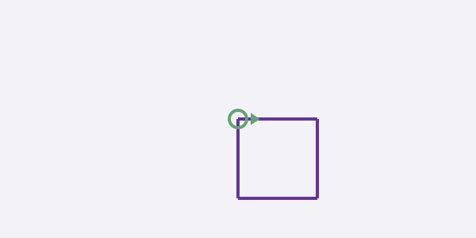

The first side goes east. Turning right then points the turtle south, so the square goes downward. With `left(90)` instead of `right(90)`, the same square would be drawn above the starting line.

### Question 7 (medium): what happens?

Assume you have just restarted the notebook and run only the setup cells (at the start of the Questions), and then this code.

```python
from jupyturtle import make_turtle, forward
make_turtle()
forward(50)
jupyturtle.left(90)
forward(50)
```

Answer

The turtle draws one line, `50` units to the east, and then Python stops with a `NameError`:

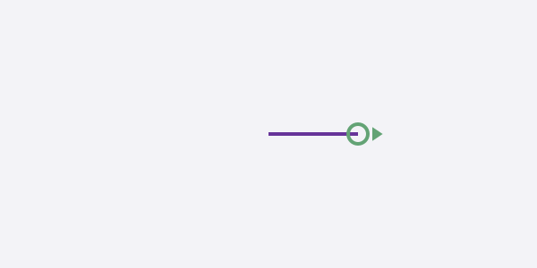

```
      2 make_turtle()
      3 forward(50)
----> 4 jupyturtle.left(90)
      5 forward(50)

NameError: name 'jupyturtle' is not defined
```

`from jupyturtle import make_turtle, forward` defines the names `make_turtle` and `forward`, but not the name `jupyturtle`. To call `jupyturtle.left`, you need `import jupyturtle`. Or import `left` as well and call `left(90)`. The last line, `forward(50)`, never runs.

### Question 8 (medium): what is displayed?

```python
def inner(angle):
    angle = angle / 2
    print('inner:', angle)

def outer(angle):
    inner(angle)
    print('outer:', angle)

outer(90)
```

Answer

```
inner: 45.0
outer: 90
```

Parameters are local. `angle` in `inner` and `angle` in `outer` are two different variables, so changing one does not change the other. `outer`’s `angle` is still the integer `90`; `inner`’s is the float `45.0`.

### Question 9 (medium): what is displayed?

```python
def c(x):
    print('c starts with', x)

def b(x):
    print('b starts with', x)
    c(x * 2)
    print('b ends with', x)

def a(x):
    print('a starts with', x)
    b(x + 1)
    print('a ends with', x)

a(3)
```

Answer

```
a starts with 3
b starts with 4
c starts with 8
b ends with 4
a ends with 3
```

When a function calls another, it waits for that call to finish before going on. Each function has its own `x`, so after the calls return, `b`’s `x` is still `4` and `a`’s is still `3`.

### Question 10 (medium): write a function

Write a function called `star` that takes a parameter `length` and draws a five-pointed star whose lines have that length.

Hint: the turtle draws 5 lines and turns the same angle after each one. In total it turns around twice (720 degrees).

Start from this header (replace `...` with the body):

```python
def star(length):
    ...
```

**Examples**

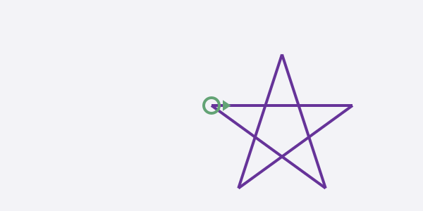

```python
make_turtle()
star(100)
```

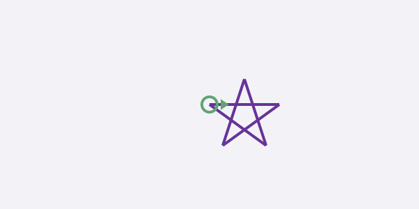

```python
make_turtle()
star(50)
```

Answer

Each turn is 720 / 5 = 144 degrees:

```python
from jupyturtle import forward, right

def star(length):
    for i in range(5):
        forward(length)
        right(144)
```

Then try: `make_turtle()` and `star(100)`.

Turning `left(144)` instead also draws a star, flipped upside down. Another approach: a general function that draws `n` lines with a given turn between them, then `star` uses it:

```python
from jupyturtle import forward, right

def polyline(n, length, angle):
    for i in range(n):
        forward(length)
        right(angle)

def star(length):
    polyline(5, length, 144)
```

### Question 11 (medium): write a function

Write a function called `row_of_squares` that takes `n` and `length` and draws `n` squares in a row, side by side and touching, each with side length `length`.

Run this cell to define `square` and `jump`.

```python
def square(length):
    for i in range(4):
        forward(length)
        left(90)

def jump(length):
    """Move forward length units without drawing."""
    penup()
    forward(length)
    pendown()
```

Start from this header (replace `...` with the body):

```python
def row_of_squares(n, length):
    ...
```

**Examples** (`jump(-150)` first moves the turtle left, so the row fits on the canvas)

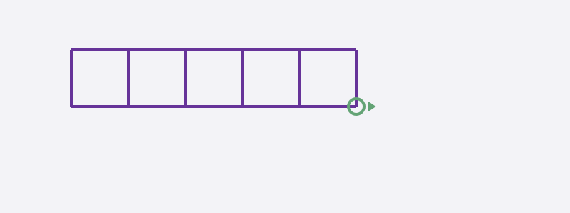

```python
make_turtle(width=400)
jump(-150)
row_of_squares(5, 40)
```

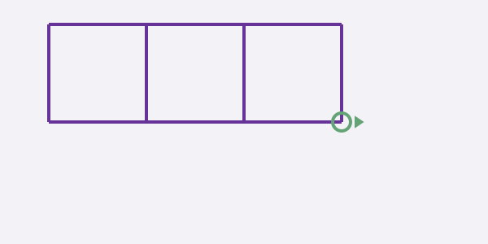

```python
make_turtle()
jump(-120)
row_of_squares(3, 60)
```

Answer

`square` leaves the turtle where it started, facing east, so after each square, jump to the start of the next one:

```python
def row_of_squares(n, length):
    for i in range(n):
        square(length)
        jump(length)
```

Then try: `make_turtle(width=400)`, `jump(-150)` and `row_of_squares(5, 40)`.

Using `forward(length)` instead of `jump(length)` draws the same picture, because the turtle moves along a bottom edge it has just drawn. `jump` makes the intention clearer: move without drawing.

### Question 12 (medium): write a function with a docstring

Write a function called `staircase` that takes `steps` and `size` and draws a staircase going up and to the right: for each step, it goes up `size` units and then right `size` units. Give it a docstring that explains its interface (what it does and what each parameter means).

Start from this header (replace `...` with the body):

```python
def staircase(steps, size):
    ...
```

**Examples**

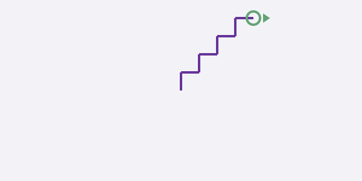

```python
make_turtle()
staircase(4, 15)
```

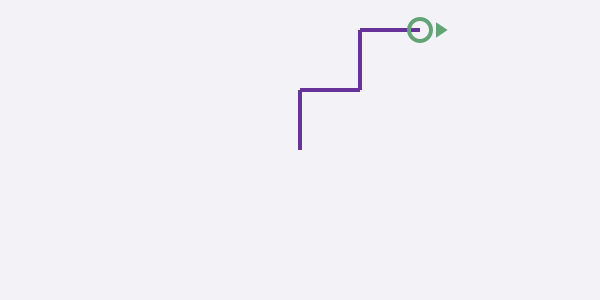

```python
make_turtle()
staircase(2, 30)
```

`help` displays a function’s docstring. Yours will have your own wording; for example:

```python
help(staircase)
```

```
Help on function staircase in module __main__:

staircase(steps, size)
    Draw a staircase going up and to the right.

    steps: number of steps (a positive integer)
    size: height and depth of each step
```

Answer

```python
from jupyturtle import forward, left, right

def staircase(steps, size):
    """Draw a staircase going up and to the right.

    steps: number of steps (a positive integer)
    size: height and depth of each step
    """
    for i in range(steps):
        left(90)
        forward(size)
        right(90)
        forward(size)
```

Then try: `make_turtle()` and `staircase(4, 15)`.

The docstring says *what* the function does, not how, and what each parameter means. The turtle starts facing east, so each step turns left (to face north), goes up, turns right (back to east) and goes forward.

### Question 13 (hard): what is displayed?

```python
def square_txt(length):
    print('square', length)

def growing(n, length):
    for i in range(n):
        square_txt(length)
        length = length * 2
    print('growing ends with', length)

length = 5
growing(3, length)
print('outside:', length)
```

Answer

```
square 5
square 10
square 20
growing ends with 40
outside: 5
```

Inside `growing`, `length` is a local variable. Assigning to it changes the value used in the next time through the loop, and after the loop it has been doubled 3 times (5, 10, 20, 40). The `length` outside the function is a different variable, so it is still `5`.

### Question 14 (hard): preconditions

`polygon`’s docstring states its preconditions.

Run this cell to define `polygon`.

```python
def polygon(n, length):
    """Draw a regular polygon.

    Preconditions: n is a positive integer; length is a positive number.
    """
    angle = 360 / n
    for i in range(n):
        forward(length)
        left(angle)
```

Two correct ways to use it:

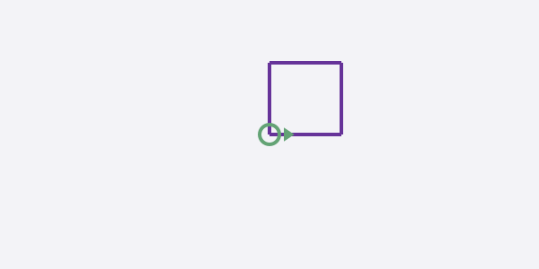

```python
make_turtle()
polygon(4, 40)
```

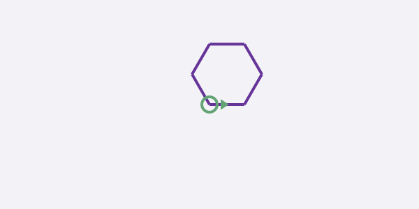

```python
make_turtle()
polygon(n=6, length=25)
```

For each of the three parts, predict what happens. Then say whether the bug is in the caller or in `polygon`.

**Part a**

```python
make_turtle()
polygon(4.5, 20)
```

**Part b**

```python
make_turtle()
polygon(0, 20)
```

**Part c**

```python
make_turtle()
polygon(-4, 20)
```

Answer

**Part a:** `angle = 360 / 4.5` works (it is `80.0`), but `range(4.5)` fails, so nothing is drawn (a `TypeError`):

```
      1 make_turtle()
----> 2 polygon(4.5, 20)

In polygon(n, length):
      5     """
      6     angle = 360 / n
----> 7     for i in range(n):
      8         forward(length)
      9         left(angle)

TypeError: 'float' object cannot be interpreted as an integer
```

**Part b:** `360 / 0` fails before anything is drawn (a `ZeroDivisionError`):

```
      1 make_turtle()
----> 2 polygon(0, 20)

In polygon(n, length):
      4     Preconditions: n is a positive integer; length is a positive number.
      5     """
----> 6     angle = 360 / n
      7     for i in range(n):
      8         forward(length)

ZeroDivisionError: division by zero
```

**Part c:** No error, and nothing is drawn: `angle` is `-90.0` and `range(-4)` is empty, so the loop body never runs. This is the most dangerous case, because nothing tells you something is wrong.

In all three parts the caller broke a precondition, so **the bug is in the caller**, not in `polygon`.

### Question 15 (hard): keyword arguments

Run this cell to define `describe`.

```python
def describe(shape, sides):
    print('A', shape, 'has', sides, 'sides')
```

Two correct ways to call it:

```python
describe('hexagon', 6)
```

```
A hexagon has 6 sides
```

```python
describe(sides=5, shape='pentagon')
```

```
A pentagon has 5 sides
```

Each of the next three calls is wrong in a different way. Predict the error for each, then open the Answer to check.

**Part a**

```python
describe(shape='square', 4)
```

**Part b**

```python
describe('square', shape='box')
```

**Part c**

```python
describe('square', size=4)
```

Answer

**Part a:** Positional arguments must come before keyword arguments, so Python rejects the line before running it (a `SyntaxError`):

```
    describe(shape='square', 4)
                              ^
SyntaxError: positional argument follows keyword argument
```

**Part b:** `'square'` is assigned to the first parameter, `shape`, and then `shape='box'` tries to assign `shape` again (a `TypeError`):

```
----> 1 describe('square', shape='box')

TypeError: describe() got multiple values for argument 'shape'
```

**Part c:** `describe` has no parameter called `size`. A keyword must be one of the parameter names (`shape` or `sides`) (a `TypeError`):

```
----> 1 describe('square', size=4)

TypeError: describe() got an unexpected keyword argument 'size'. Did you mean 'sides'?
```

(Python versions before 3.13 leave out the suggestion “Did you mean ‘sides’?”.)

Some correct calls: `describe('square', 4)`, `describe(shape='square', sides=4)`, `describe(sides=4, shape='square')` and `describe('square', sides=4)`.

### Question 16 (hard): write a function

Write a function called `spiral` that takes `n`, `length`, `angle` and `increase`. It draws `n` line segments, turning left `angle` degrees after each one. The first segment has length `length`, and each segment is `increase` units longer than the one before.

Start from this header (replace `...` with the body):

```python
def spiral(n, length, angle, increase):
    ...
```

**Examples**

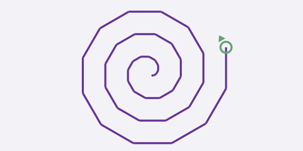

```python
make_turtle(delay=0)
spiral(40, 2, 30, 1)
```

[figure not shown]

```python
make_turtle(delay=0)
spiral(20, 5, 90, 5)
```

Answer

`length` is a local variable, so the function can change it as it goes:

```python
from jupyturtle import forward, left

def spiral(n, length, angle, increase):
    for i in range(n):
        forward(length)
        left(angle)
        length = length + increase
```

Then try: `make_turtle(delay=0)` and `spiral(40, 2, 30, 1)`.

Another approach computes each segment’s length from the loop variable, without changing `length`:

```python
from jupyturtle import forward, left

def spiral(n, length, angle, increase):
    for i in range(n):
        forward(length + i * increase)
        left(angle)
```

### Question 17 (hard): write a function

Write a function called `grid` that takes `rows`, `cols` and `size` and draws a grid of squares, `rows` high and `cols` wide, each with side length `size`. The turtle starts at the bottom-left corner of the grid, facing east.

Hint: to get from the end of one row to the start of the next, use `jump` (with a negative length to go back), `left` and `right`.

Start from this header (replace `...` with the body):

```python
def grid(rows, cols, size):
    ...
```

**Examples**

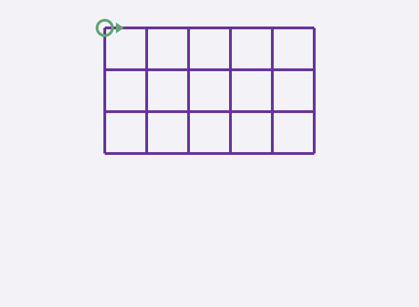

```python
make_turtle(height=220, delay=0)
jump(-75)
grid(3, 5, 30)
```

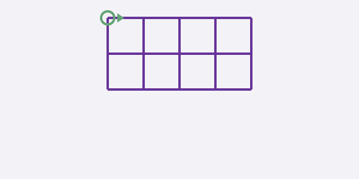

```python
make_turtle(delay=0)
jump(-60)
grid(2, 4, 30)
```

This question uses `jump` and `square` from Question 11.

Answer

Put one row in a function first, then call it once for each row:

```python
from jupyturtle import left, right

def row(cols, size):
    for i in range(cols):
        square(size)
        jump(size)

def grid(rows, cols, size):
    for i in range(rows):
        row(cols, size)
        jump(-cols * size)    # back to the start of this row
        left(90)
        jump(size)            # up to the start of the next row
        right(90)
```

Then try: `make_turtle(height=220, delay=0)`, `jump(-75)` and `grid(3, 5, 30)`.

The same thing with a loop inside a loop instead of the `row` function:

```python
from jupyturtle import left, right

def grid(rows, cols, size):
    for i in range(rows):
        for j in range(cols):
            square(size)
            jump(size)
        jump(-cols * size)
        left(90)
        jump(size)
        right(90)
```

The first version is easier to read and test, because each function does one thing and has a name that says what.

### Question 18 (hard): refactor

These two functions work, but they repeat almost all of their code.

```python
def triangle_row(n, length):
    for i in range(n):
        for j in range(3):
            forward(length)
            left(120)
        jump(length)

def square_row(n, length):
    for i in range(n):
        for j in range(4):
            forward(length)
            left(90)
        jump(length)
```

Refactor them: write one general function, `polygon_row(sides, n, length)`, that draws a row of `n` regular polygons with `sides` sides. Then rewrite `triangle_row` and `square_row` to use it, **without changing how they are called or what they draw**.

Start from this header (replace `...` with the body):

```python
def polygon_row(sides, n, length):
    ...

def triangle_row(n, length):
    ...

def square_row(n, length):
    ...
```

**Examples** (they draw the same pictures before and after the refactoring)

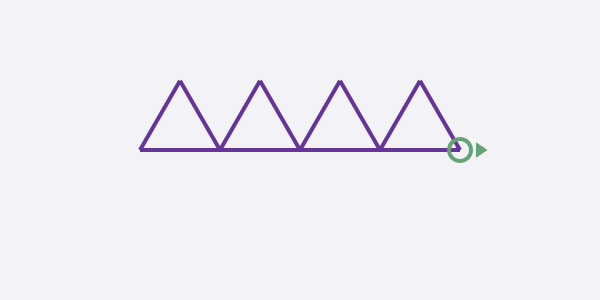

```python
make_turtle(delay=0)
jump(-80)
triangle_row(4, 40)
```

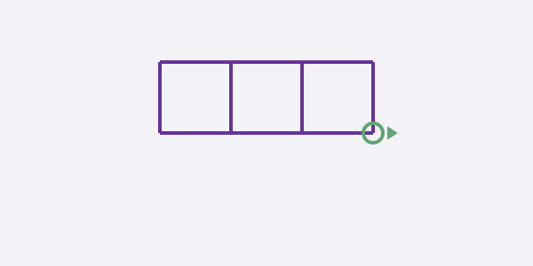

```python
make_turtle(delay=0)
jump(-60)
square_row(3, 40)
```

This question uses `jump` from Question 11, and `polygon` from Question 14.

Answer

```python
def polygon_row(sides, n, length):
    for i in range(n):
        polygon(sides, length)
        jump(length)

def triangle_row(n, length):
    polygon_row(3, n, length)

def square_row(n, length):
    polygon_row(4, n, length)
```

Then try: `make_turtle(delay=0)`, `jump(-80)` and `triangle_row(4, 40)`.

`triangle_row` and `square_row` keep the same interface (name, parameters, what they draw) with a new implementation, so any code that calls them still works. The inner loops became calls to `polygon`, which already does that job.

### Question 19 (hard): generalize a function

This function draws an arc (part of a circle) with the given `radius`, spanning `angle` degrees, as 30 short straight lines:

```python
def arc(radius, angle):
    arc_length = 2 * math.pi * radius * angle / 360
    n = 30
    length = arc_length / n
    step_angle = angle / n
    for i in range(n):
        forward(length)
        left(step_angle)
```

It always uses 30 lines: for a big circle each line is long and the circle looks jagged, and for a tiny one most lines are too short to see.

1. Write `arc_n(radius, angle, n)`, which does the same but draws `n` lines.
2. Write `circle(radius)`, which uses `arc_n` to draw a full circle, choosing `n` from the radius so that each line is about `3` units long, with at least `10` lines. (`int()` converts a float to an integer by dropping the fraction.)

Start from this header (replace `...` with the body):

```python
def arc_n(radius, angle, n):
    ...

def circle(radius):
    ...
```

**Examples**

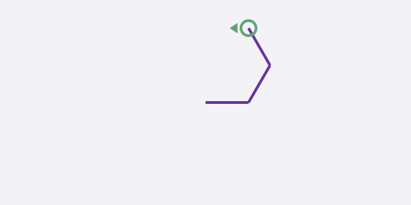

```python
make_turtle(delay=0)
arc_n(30, 180, 3)
```

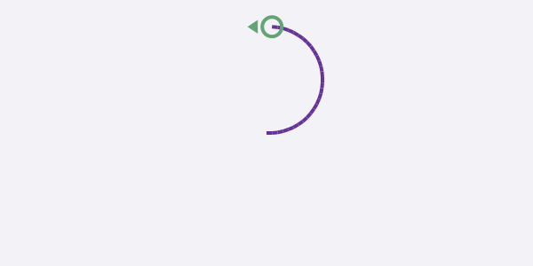

```python
make_turtle(delay=0)
arc_n(30, 180, 30)
```

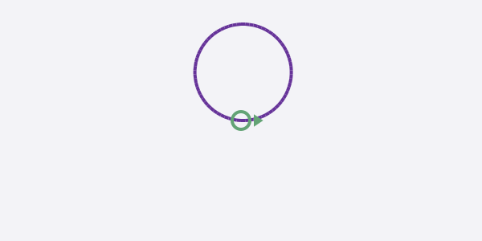

```python
make_turtle(delay=0)
circle(30)
```

Answer

```python
import math
from jupyturtle import forward, left

def arc_n(radius, angle, n):
    arc_length = 2 * math.pi * radius * angle / 360
    length = arc_length / n
    step_angle = angle / n
    for i in range(n):
        forward(length)
        left(step_angle)

def circle(radius):
    circumference = 2 * math.pi * radius
    n = int(circumference / 3) + 10
    arc_n(radius, 360, n)
```

Then try: `make_turtle(delay=0)` and `arc_n(30, 180, 3)`.

For `radius` 30 the circumference is about 188, so `n` is 62 + 10 = 72 lines; for `radius` 300 it would be 628 + 10 = 638. Adding `10` guarantees at least 10 lines, even for a tiny circle.

Another way to say “at least 10” is `max(10, int(circumference / 3))`, if you know the `max` function.

*Summary and questions by Prof. Y. Rosenthal, based on* [Think Python: 3rd Edition](https://allendowney.github.io/ThinkPython/index.html) *by Allen B. Downey.* *Text license:* [Creative Commons Attribution-NonCommercial-ShareAlike 4.0 International](https://creativecommons.org/licenses/by-nc-sa/4.0/)

Contents